# Teste RedAsset - Fabiano Calado

Fabiano Calado

Iniciado em 16/12/2020

Aqui será descrito todo o código, incluindo o raciocínio usado nas análises.

### Questão 1:

Começando com a importação dos dados:

```r
library(dplyr)
library(magrittr)
library(scales)
library(ggplot2)
library(stringr)
library(DT)
library(caret)
library(imputeTS)
library(xgboost)
table<-read.delim("BASE_TITULOS.txt")
table1 <- table[-c(15:35)]
```

A tabela table1 foi usada para visualizações comparativas e análise dos principais indicadores sem considerar as variáveis de risco.  
Após entender as variáveis que podem ser apresentadas, foi feita a tabela com os cálculos necessários.

Contabilizando os fundos por resultado:

```r
table1 %>% group_by(FUNDO=NOME_FUNDO) %>%
  summarize(
    RECEITA_TOTAL = dollar(sum(VALOR_REAL),prefix = "RS$ ",big.mark = ".",largest_with_cents = 0),
    TOTAL_DESAGIOS = dollar(sum(VALOR_DESAGIO),prefix = "RS$ ",big.mark = ".",largest_with_cents = 0),
    TAXA_MEDIA=percent(mean(TAXA_MENSAL,na.rm = TRUE),accuracy = 0.1),
    ROI = percent(sum(VALOR_DESAGIO)/sum(VALOR_REAL),accuracy = 0.1),
    NUM_TITULOS=n(),
    PAGO_EM_DIA = percent(mean(STATUS_LIQ_TITULO=="EM_DIA"),accuracy = 0.1)
  ) %>% datatable()
```

|  | FUNDO | RECEITA_TOTAL | TOTAL_DESAGIOS | TAXA_MEDIA | ROI | NUM_TITULOS | PAGO_EM_DIA |
| --- | --- | --- | --- | --- | --- | --- | --- |
| 1 | Fundo 1 | RS$ 25.976.411 | RS$ 1.928.355 | 4.7% | 7.4% | 6005 | 84.3% |
| 2 | Fundo 2 | RS$ 31.727.330 | RS$ 2.382.740 | 4.9% | 7.5% | 2628 | 88.2% |
| 3 | Fundo 3 | RS$ 329.850 | RS$ 21.639 | 2.6% | 6.6% | 306 | 27.5% |
| 4 | Fundo 4 | RS$ 1.981.532 | RS$ 220.915 | 3.9% | 11.1% | 472 | 16.7% |
| 5 | Fundo 5 | RS$ 561.044 | RS$ 19.308 | 0.5% | 3.4% | 4 | 100.0% |

A taxa média é uma média simples das taxas dos títulos de cada fundo. A taxa de retorno é o total de deságio em relação ao total dos títulos.  
A taxa de retorno (ROI) maior que a média indica que os títulos mais caros foram negociados com taxas mais altas.  
É possível também observar que os fundos 3 e 4 estão com uma taxa de atraso alta. São fundos menores que não impactam tanto na receita total, mas precisam melhorar nesse quesito.

Agora, analisando a carteira por regionalidade:

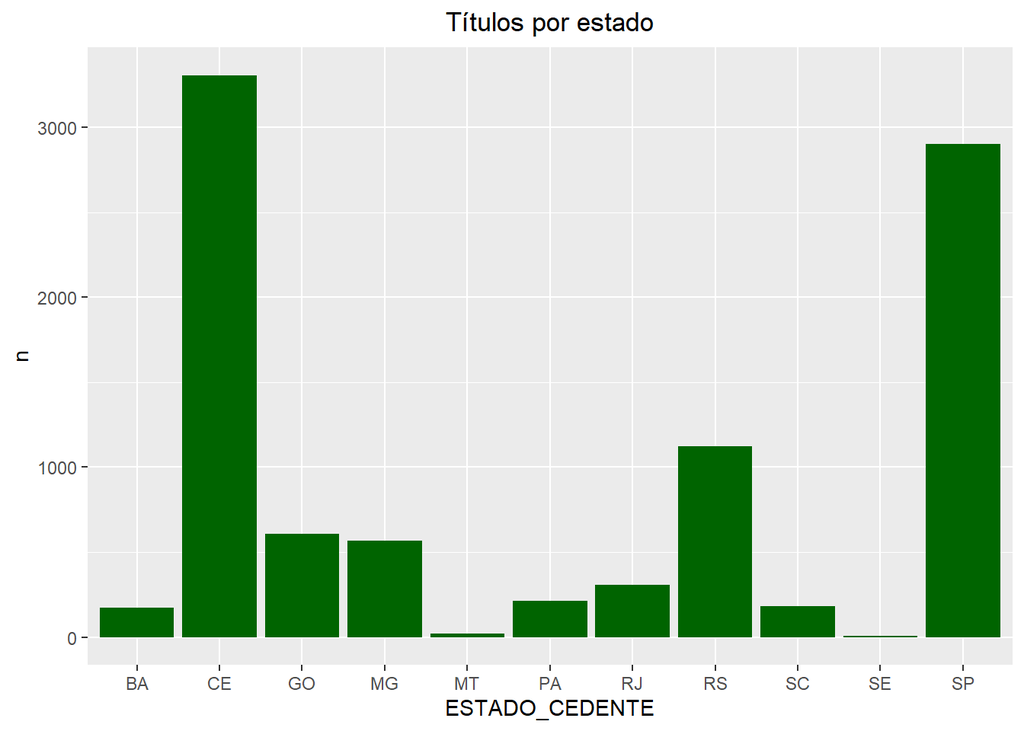

```r
table1 %>% count(ESTADO_CEDENTE,sort=TRUE) %>%
  ggplot(aes(ESTADO_CEDENTE,y=n))+
  geom_bar(stat = "identity", fill="darkgreen") +
  ggtitle("Títulos por estado")+
  theme(plot.title = element_text(hjust = 0.5))
```

[figure not shown]

```r
table1 %>% group_by(ESTADO_CEDENTE) %>%
  ggplot(aes(ESTADO_CEDENTE,y=sum(VALOR_REAL)/1000000000))+
  geom_bar(stat = "identity", fill="darkgreen") +
  ggtitle("Receita por estado")+
  theme(plot.title = element_text(hjust = 0.5))+
  ylab("R$ Bilhões")
```

Ranking de clientes por títulos:

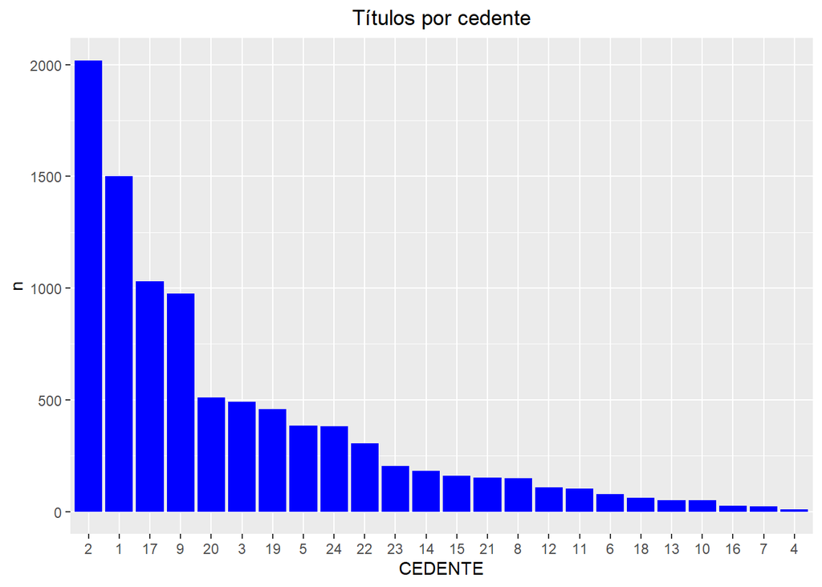

```r
plot <- table1 %>% count(CEDENTE,sort = TRUE)
plot$CEDENTE <- str_sub(plot$CEDENTE,start = 9)
plot$CEDENTE <- factor(plot$CEDENTE, levels = plot$CEDENTE[order(plot$n,decreasing = TRUE)])
plot %>%
  ggplot(aes(CEDENTE,y=n))+
  geom_bar(stat = "identity", fill="blue") +
  ggtitle("Títulos por cedente")+
  theme(plot.title = element_text(hjust = 0.5))
```

### Questão 2:

Indicadores iniciais escolhidos para teste:

- Taxa de inadimplência: A taxa de atraso dos títulos do Cedente é um indicador do critério de crédito do Cedente e impacta diretamente no lucro.
- Taxa média mensal: Pode ser usada para medir a lucratividade dos títulos do Cedente. O deságio é proporcional à taxa.
- Quantidade de títulos: Será usada como métrica de relacionamento com o cliente.
- Valor médio do título: Outro indicador de lucratividade dos contratos. O deságio é proporcional ao valor real.

O algoritmo selecionado é o k-means, que é o mais usado para segmentação com dados numéricos.  
Foi preparada uma nova tabela para receber os dados:

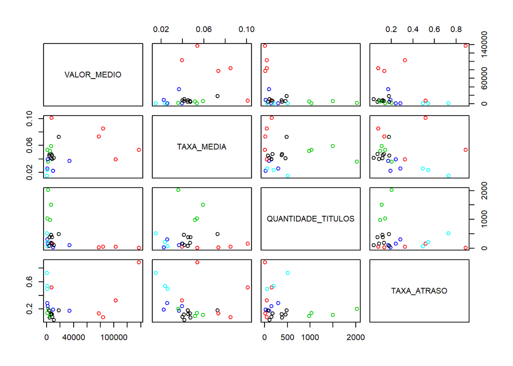

```r
table2 <- table1 %>% group_by(CEDENTE) %>%
  summarize(
    VALOR_MEDIO = sum(VALOR_REAL)/n(),
    TAXA_MEDIA=mean(TAXA_MENSAL,na.rm = TRUE),
    QUANTIDADE_TITULOS=n(),
    TAXA_ATRASO = mean(STATUS_LIQ_TITULO=="ATRASO"),
  )

#CLUSTERING:
set.seed(638416)
agrup <- kmeans(na.omit(scale(table2[,-1])),5)
plot(table2[,-1],col=agrup$cluster)
```

```r
agrup$size
```

```
## [1] 8 5 4 4 3
```

```r
table2$cluster = factor(agrup$cluster)
```

Após fazer a escala nos dados os clusters ficaram mais definidos. Aumentar quantidade de grupos não foi bom, porque aparecem grupos com apenas 1 Cedente.  
É possível observar pelos gráficos que os Cedentes estão segmentados de acordo com o resultado dos títulos (de acordo com os indicadores determinados acima).

Há 2 grupos com os maiores valores de taxa média, valor e quantidade.  
Visualizando o agrupamento, não vi necessidade de realizar a segmentação usando os indicadores individualmente:

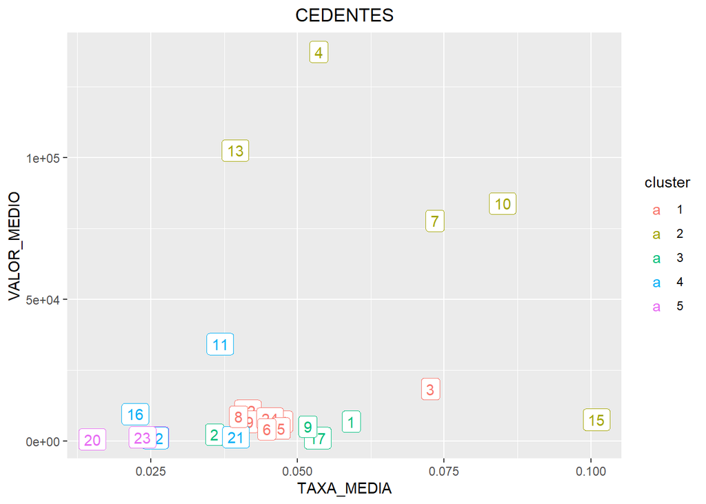

```r
table2$CEDENTE <- factor(str_sub(table2$CEDENTE,start = 9))
table2 %>%
ggplot(aes(x=TAXA_MEDIA,y=VALOR_MEDIO,label=CEDENTE,color=cluster))+
  geom_label(stat = "identity") +
  ggtitle("CEDENTES")+
  theme(plot.title = element_text(hjust = 0.5))
```

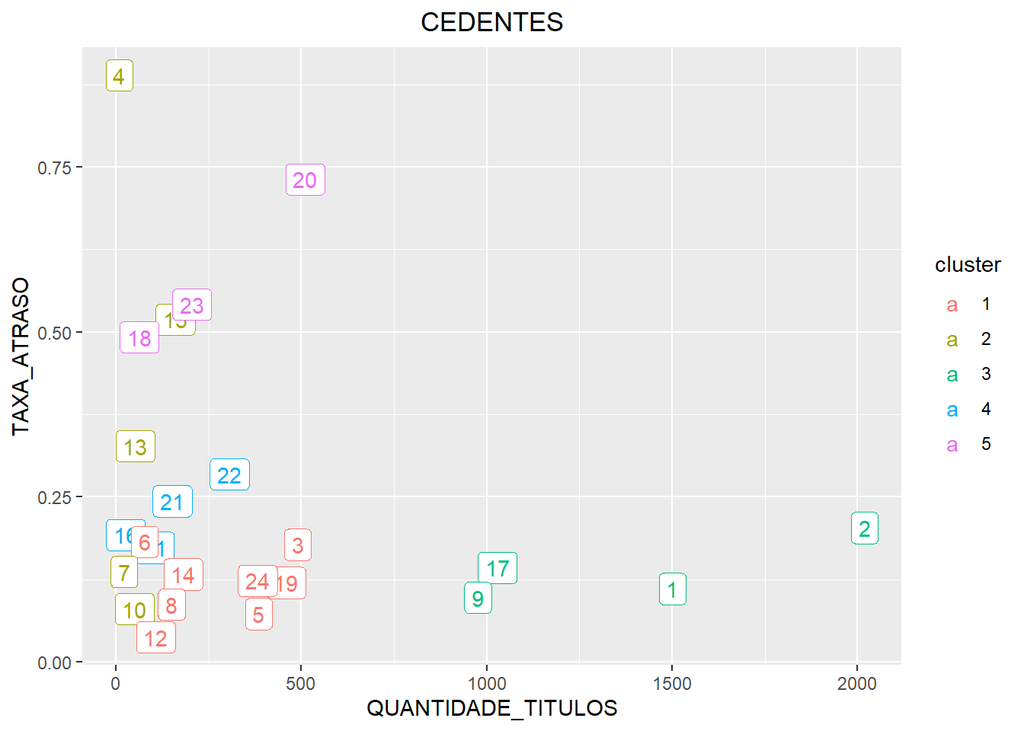

```r
table2 %>%
ggplot(aes(x=QUANTIDADE_TITULOS,y=TAXA_ATRASO,label=CEDENTE,color=cluster))+
  geom_label(stat = "identity") +
  ggtitle("CEDENTES")+
  theme(plot.title = element_text(hjust = 0.5))
```

Caso os grupos ficassem muito misturados, o algoritmo poderia ser usado separadamente em alguns indicadores, para categorizar os Cedentes com perfil parecido na variável desejada, sem influência dos demais indicadores.

### Questão 3:

Para o primeiro teste, foi usado o método SVM com k-fold, tratando os valores ausentes (NA) substituindo pelo valor médio. O tempo de execução estava muito alto, então o teste foi refeito trocando o algoritmo pelo XGBoost para comparar as variáveis de risco. Foi observado que existe uma grande quantidade de valores vazios nas variáveis de risco (foram substituídos pela média). O XGBoost, por ser um algoritmo de rápida execução, permite fazer muitos testes, e o tratamento das variáveis antes do algoritmo geralmente mais diferença no resultado do que a escolha do algoritmo em si, mas não havia tempo suficiente para analisar correlações e eficiência de cada variável.

Primeiro foi feito um teste sem as variáveis de risco, para controle. Código:

```r
set.seed(920)
t3 <- table %>%
  select(
    TIPO_PRODUTO,CEDENTE,SACADO,ESTADO_CEDENTE,ESTADO_SACADO,DATA_EMISSAO, DATA_PAGAMENTO, VENCIMENTO,
    VALOR_REAL, TAXA_MENSAL, c(11:14,36)
  ) %>% na_mean()
#dividindo train data e normalizando os valores

t3[1:8] <- as.numeric(factor(as.matrix(t3[1:8])))
t3$STATUS_LIQ_TITULO <- as.numeric(factor(as.matrix(t3$STATUS_LIQ_TITULO)))-1
t3[1:(ncol(t3)-1)] <- scale(t3[1:(ncol(t3)-1)])
tt <- head(t3, 7000)

dtrain <- xgb.DMatrix(label = tt$STATUS_LIQ_TITULO, data = as.matrix(tt[,-ncol(tt)]))
model <-xgboost(data = dtrain, max.depth = 10, eta = 1, nthread = 2, nrounds = 5, objective = "binary:logistic")
pred <- as.numeric(predict(model,xgb.DMatrix(as.matrix(t3[7001:9415,-ncol(t3)])))>0.5)
err <- abs(pred - t3[7001:9415,ncol(t3)])
sum(err)/2415
```

```
## [1] 0.1544513
```

Após isso, foram feitos testes com todas variáveis de risco, e alguns testes parciais. A medida de erro escolhida é o percentual de previsões incorretas em relação ao total.

Então os setuintes testes foram feitos:

- Todas as variáveis de risco: erro aumentou de 15,4% para 16%
- Com RISCO_6 A RISCO_21: aumentou para 17%

Partindo dessa observação, foram feitos alguns testes com menos variáveis de risco, e no teste com as variáveis RISCO_1 A RISCO_7 o erro caiu para 14%.

Último teste:

```r
set.seed(920)
t3 <- table %>%
  select(
    TIPO_PRODUTO,CEDENTE,SACADO,DATA_EMISSAO, VENCIMENTO,
    TAXA_MENSAL, c(11:21,36)
  ) %>% na_mean()
#dividindo train data e normalizando os valores

t3[1:7] <- as.numeric(factor(as.matrix(t3[1:7])))
t3$STATUS_LIQ_TITULO <- as.numeric(factor(as.matrix(t3$STATUS_LIQ_TITULO)))-1
t3[1:(ncol(t3)-1)] <- scale(t3[1:(ncol(t3)-1)])
tt <- head(t3, 7000)

dtrain <- xgb.DMatrix(label = tt$STATUS_LIQ_TITULO, data = as.matrix(tt[,-ncol(tt)]))
model <-xgboost(data = dtrain, max.depth = 10, eta = 0.6, nthread = 2, nrounds = 5, objective = "binary:logistic")
pred <- as.numeric(predict(model,xgb.DMatrix(as.matrix(t3[7001:9415,-ncol(t3)])))>0.5)
err <- abs(pred - t3[7001:9415,ncol(t3)])
sum(err)/2415
```

```
## [1] 0.1246377
```

Conclusão: O erro de 12% já não é ruim (considerando que os dados são bastante heterogêneos e que o erro na base de treino foi 10%), mas ainda há idéias para melhorar a qualidade da previsão:

- Verificar quais variáveis são realmente necessárias
- Usar o prazo do título como variável e comparar o resultado
- Testar outros métodos (random forest, SVM, etc).

Pela minha experiência em competições de Machine Learning, o que mais faz diferença no modelo é a seleção e preparação das variáveis, e a remoção e transformação de variáveis nesse problema mostrou uma grande diferença no resultado final.

#### Concluído em 18/12/2020